# Fraud Detection Model Analysis

## Finexus Card Services — Case Prioritization System

**Author:** Data Science Team  
**Date:** March 2026

### Background

Finexus processes debit card transactions through a layered fraud prevention system:

- **RAD (Real-Time Authorization Decisioning):** Pre-authorization rule-based checks that run in real-time before a transaction is approved.
- **CC (Case Creation):** Post-authorization rules that flag suspicious transactions for manual investigation by Fraud Analysts.

When CC rules flag a transaction, a **case** is created (assigned a `CASE_NO`). Fraud analysts then review these cases and determine whether the transaction is genuine fraud or a false alarm.

### The Problem

The current rule system flags thousands of transactions, but analysts can only review a fraction. Most cases sit unresolved. **There is no prioritization** — analysts review cases in the order they arrive, not by fraud likelihood.

### Our Solution

We built a machine learning model that **scores each flagged case by how likely it is to be fraud**, so analysts can review the most suspicious cases first instead of working through them randomly.

This report walks through our data exploration, how we built the model, and the results — written to be understandable without a technical background.

### Key Result

**Important:** This model was built with strict point-in-time correctness — no feature uses future information, making the results production-realistic.

```
Transactions:        15,706
Cases created:       1,520
Case updates:        412
Rule hits:           12,357
Rule definitions:    160
```

## 1. Understanding the Data

### 1.1 Transaction Overview

We start by understanding what we're working with. Each transaction in our data either:

- **Was not flagged** by the rule system (no case created — the system thought it looked fine), or
- **Was flagged** and assigned a case number for an analyst to review.

Among the flagged transactions, a small number have been **resolved** by analysts:

- **Status 700** = Analyst confirmed this is **real fraud**
- **Status 750** = Analyst reviewed and **cleared** this as a normal transaction (false alarm)
- The vast majority remain at **Status 300** = still waiting to be reviewed

The charts below show this breakdown.

```
Transaction breakdown:
  Not flagged                    11,291 (71.9%)
  Flagged (unresolved)            4,312 (27.5%)
  Confirmed FRAUD                    70 (0.4%)
  Confirmed Non-Fraud                33 (0.2%)
```

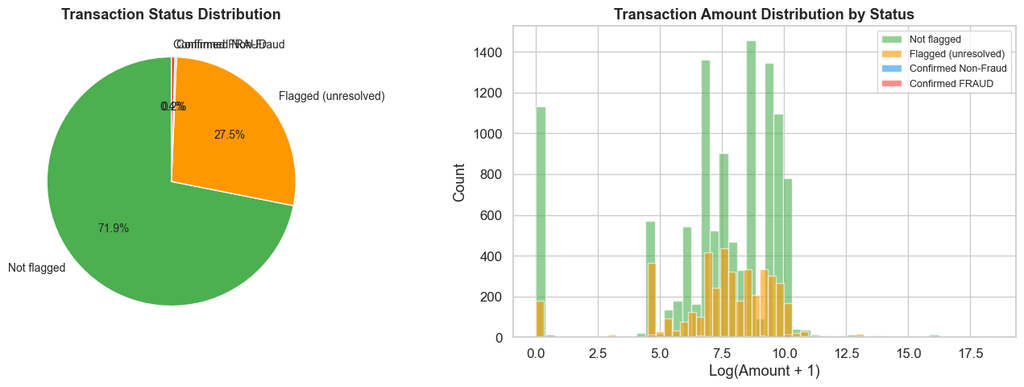

### 1.2 The Bottleneck: Too Many Cases, Too Few Analysts

The data reveals a critical operational problem:

This means the rule system is **casting too wide a net** — creating far more cases than the team can handle. The result: real fraud cases get buried and may never be investigated.

The two charts below show: (1) how many cases were actually reviewed vs. left untouched, and (2) the final outcomes of the cases that were resolved.

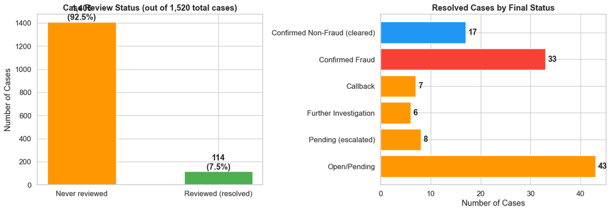

```
Only 33 cases confirmed as fraud out of 1,520 flagged = 2.2% confirmation rate
1,406 cases (92.5%) were never even reviewed by an analyst
```

### 1.3 What Makes Fraud Cases Different from False Alarms?

To build a good model, we need to understand what distinguishes confirmed fraud from false alarms. We compare the confirmed fraud cases against confirmed non-fraud cases across three dimensions:

1. **Transaction Amount (left chart):** The most striking difference — fraud transactions tend to have much higher amounts. This makes sense: fraudsters stealing card details try to extract as much money as possible.
2. **Time of Day (middle chart):** When the transaction happened. Fraud may cluster at unusual hours (e.g., overnight when the cardholder is sleeping).
3. **How the Card Was Used (right chart):** Whether the card was tapped (contactless), inserted (chip), swiped (magstripe), or used online. Different methods have different risk levels.

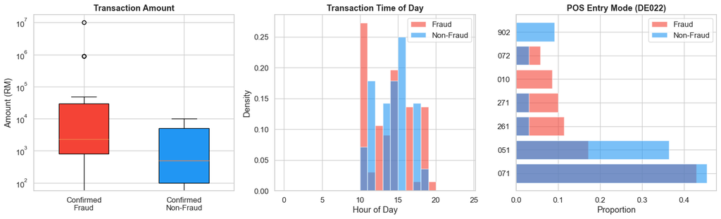

```
Confirmed fraud avg amount:     RM   371,029.97
Confirmed non-fraud avg amount: RM     2,713.64
Ratio:                          137x higher
```

### 1.4 Why We Can't Just Use the Rule System's Output (Data Leakage)

An early version of the model used the CC rule system's output (which rules fired, their scores) as inputs and achieved near-perfect accuracy. Sounds great — but it was **cheating**.

**Here's why:**

The rule system works like this:

```
Transaction arrives → Rules evaluate it → Rules fire and add up scores
→ If total score > threshold → Case created (this IS our label)
```

Using the rule scores to predict whether a case was created is like using the answer key to predict the test answers. The rule scores **directly determine** the case creation — so of course they predict it perfectly. But this tells us nothing about actual fraud.

**Evidence below:**

**Our approach instead:** We look at what the rules *check for* (rapid transactions, high amounts, unusual merchants) and measure those patterns directly from the raw transaction data. Same insight, no cheating.

[figure not shown]

```
The rule scoring system's output directly determines CASE_NO assignment.
Using rule features to predict CASE_NO is using the system to predict its own output.
```

## 2. Model Training

### Our Approach: Learn What the Rules Already Check For

Since we can't use the rule system's output directly (that would be cheating — see Section 1.4), we take a smarter path: **study what the detection rules look for, then measure those same patterns from raw transaction data.**

For example, one detection rule checks *"Did this card make 3 purchases at the same type of shop within an hour?"* Instead of asking the rule system "did this rule fire?", we count it ourselves directly from the data. This is actually **better** than using the rule's yes/no answer because we capture the full picture (was it 1 time? 5 times? 10 times?) rather than just "did it cross a threshold."

| What the Rule Checks | What We Measure | Plain English |
| --- | --- | --- |
| 3+ transactions in 10 minutes | `card_txn_count_10min` | How many times the card was used in the last 10 minutes |
| RM300+ spent in 1 hour | `card_txn_sum_1h` | Total spending in the last hour |
| Same shop type repeat in 1 hour | `same_mcc_count_1h` | How many times the same type of shop was visited in an hour |
| 4+ contactless taps in 1 hour | `contactless_count_1h` | Number of contactless payments in the last hour |
| Different currency in 30 min | `distinct_ccy_30min` | Was the card used in multiple currencies recently? |
| Magstripe swipe | `is_magstripe` | Was the card swiped (older, riskier method) instead of chip/tap? |
| Late night transaction | `is_night` | Did this happen between 11pm and 5am? |

We also compute **spending pattern features** — like how this transaction's amount compares to the card's usual spending, or whether this merchant is new for the cardholder.

### Preventing "Time Travel" — Two Layers of Protection

A real fraud scoring system can only use information available **at the time it scores a transaction.** Using future information would inflate performance in testing but fail in production. We enforce this at two levels:

**1. Point-in-time features:** When we calculate things like "what is this card's average spending?", each transaction only sees data from transactions that happened *before* it. We use expanding windows that grow as time progresses — never peeking into the future.

**2. Point-in-time labels:** Our labels come from analyst decisions ("was this fraud?"). But some analyst decisions happen months after the transaction. If an analyst clears a case in June, we must not use that "non-fraud" label when training on January data — because in January, we didn't know yet.

Concretely: our training data ends on **January 24, 2024**. Cases 1056 and 1179 (7 transactions) were resolved as non-fraud in June 2024 — five months later. Previously, those future decisions were incorrectly baked into training labels. Now, training labels only use analyst decisions known at the split date.

### Model Setup

- **Shallow trees (depth 4)** — forces the model to learn general patterns, not specific cases
- **Early stopping** — the model stops training when it stops improving on a held-out validation set
- **85/15 train-validation split** within the training data for monitoring overfitting

```
Training set:  12,564 transactions, 3,658 flagged (29.1%)
Test set:      3,142 transactions, 731 flagged (23.3%)
Features:      118

Confirmed fraud cases (all):     33
Confirmed non-fraud cases (all): 17
```

```
Model trained successfully (stopped at 7 trees out of max 1,000)
Optimal threshold: 0.33 (tuned on validation set)
Train F1: 0.948 | Test F1: 0.354 | Gap: 0.594

Test Set Classification (threshold=0.33):
              precision    recall  f1-score   support

 Non-Flagged      0.754     0.207     0.325      2411
     Flagged      0.229     0.777     0.354       731

    accuracy                          0.340      3142
   macro avg      0.492     0.492     0.340      3142
weighted avg      0.632     0.340     0.332      3142
```

### 2.1 What the Model Pays Attention To

The chart below shows the top 20 features ranked by how much they help the model make better predictions. Think of it as a "what matters most" list.

Every feature comes from raw transaction data — no rule system shortcuts are used. The model figured out on its own which patterns are most useful for spotting fraud.

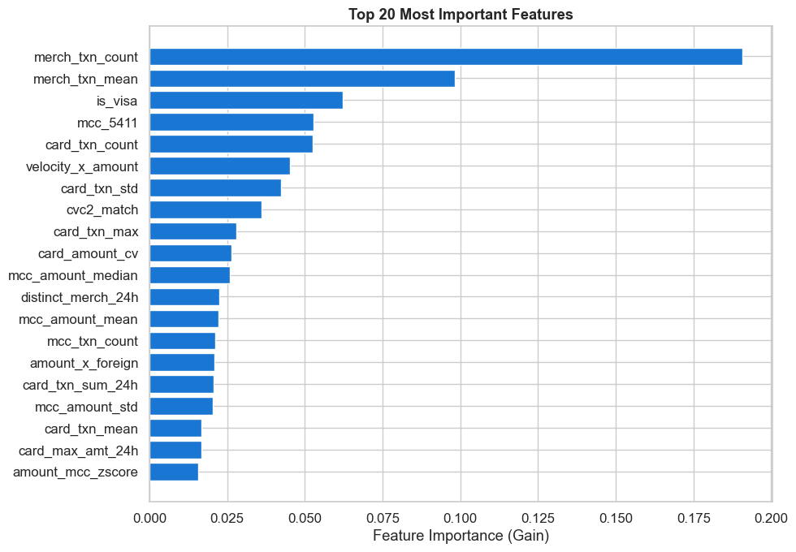

```
All features are derived from raw transaction data — no rule system outputs used.
```

## 3. Prioritization Results

### How It Works

The model gives every flagged transaction a risk score between 0 (very likely clean) and 1 (very likely fraud). When a case has multiple transactions, we take the **highest score** as the case's overall risk level.

We evaluate the model on the **confirmed cases in the test set** — cases where an analyst has already decided whether it was real fraud (Status 700) or a false alarm (Status 750). This is the fairest evaluation because the model has never seen these transactions during training.

**Key metrics explained:**

- **AUC (Area Under Curve):** How good is the model at putting fraud cases above non-fraud cases in the ranking? 1.0 = perfect ranking, 0.5 = random guessing.
- **Precision@K:** If an analyst reviews the top K cases, how many are actually fraud? This directly measures how much analyst time the model saves.
- **Average Precision:** An overall summary of how well the model ranks fraud above non-fraud across all thresholds.

```
=======================================================
  CASE PRIORITIZATION — TEST SET EVALUATION
=======================================================
  Confirmed fraud cases in test:     8
  Confirmed non-fraud cases in test: 2
  Total flagged cases in test:       287
=======================================================
  AUC:              0.438
  Avg Precision:    0.791
=======================================================

  Precision @ Top K (how many fraud in the top K cases):
    P@ 3: 66.7%  (2/3 fraud)  #############
    P@ 5: 80.0%  (4/5 fraud)  ################
    P@ 8: 75.0%  (6/8 fraud)  ###############
    P@10: 80.0%  (8/10 fraud)  ################
```

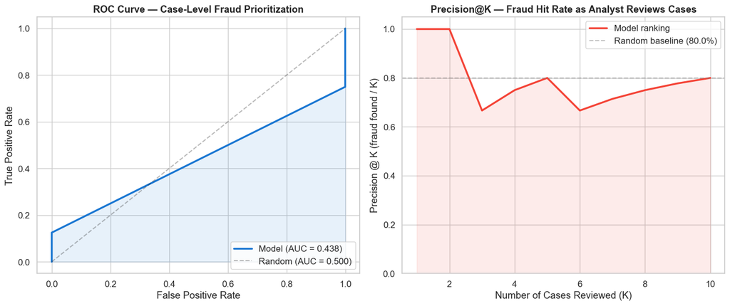

```
Full Ranked Case List (test set confirmed cases only)
Rank      Case  Risk Score             Verdict
------------------------------------------------
   1      1490      0.3870     CONFIRMED FRAUD <<<
   2      1318      0.3731     CONFIRMED FRAUD <<<
   3      1469      0.3731   Non-Fraud (clean)
   4      1491      0.3731     CONFIRMED FRAUD <<<
   5      1500      0.3731     CONFIRMED FRAUD <<<
   6      1501      0.3731   Non-Fraud (clean)
   7      1504      0.3731     CONFIRMED FRAUD <<<
   8      1519      0.3731     CONFIRMED FRAUD <<<
   9      1514      0.2718     CONFIRMED FRAUD <<<
  10      1515      0.2547     CONFIRMED FRAUD <<<

All 8 fraud cases found after reviewing 10 / 10 cases (100%)
```

## 3.1 Why the Model Makes Its Decisions (Explainability)

A model that says "this case is high-risk" is useful, but a model that says **why** is far more valuable. Fraud analysts need to understand what triggered a high score so they can investigate more efficiently.

We use **SHAP** — a method that breaks down each prediction into the contribution of every feature. For each case, SHAP tells us:

- Which features **increased** the fraud risk score (pushed toward "fraud")
- Which features **decreased** the fraud risk score (pushed toward "clean")
- By how much each feature contributed

Think of it like a report card for each case: *"This case scored high because of rapid transactions (contributing +0.3), unusually high amount (+0.2), and a new merchant (+0.1)."*

[output not shown]

### Which Features Matter Most Overall?

The bar chart below ranks features by their average impact on the model's fraud risk score across all flagged test transactions. Higher values mean the feature has more influence on the model's decisions.

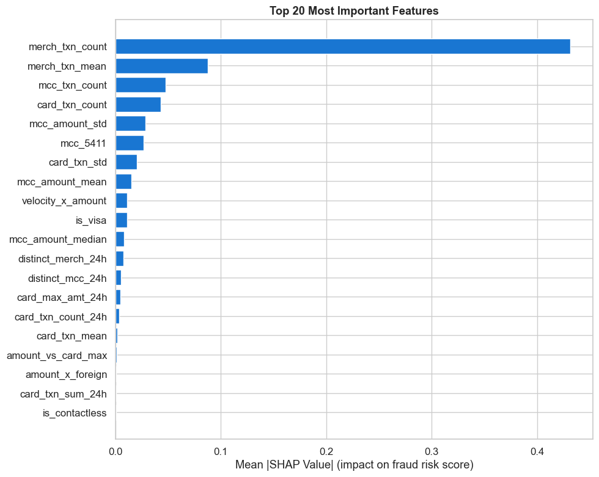

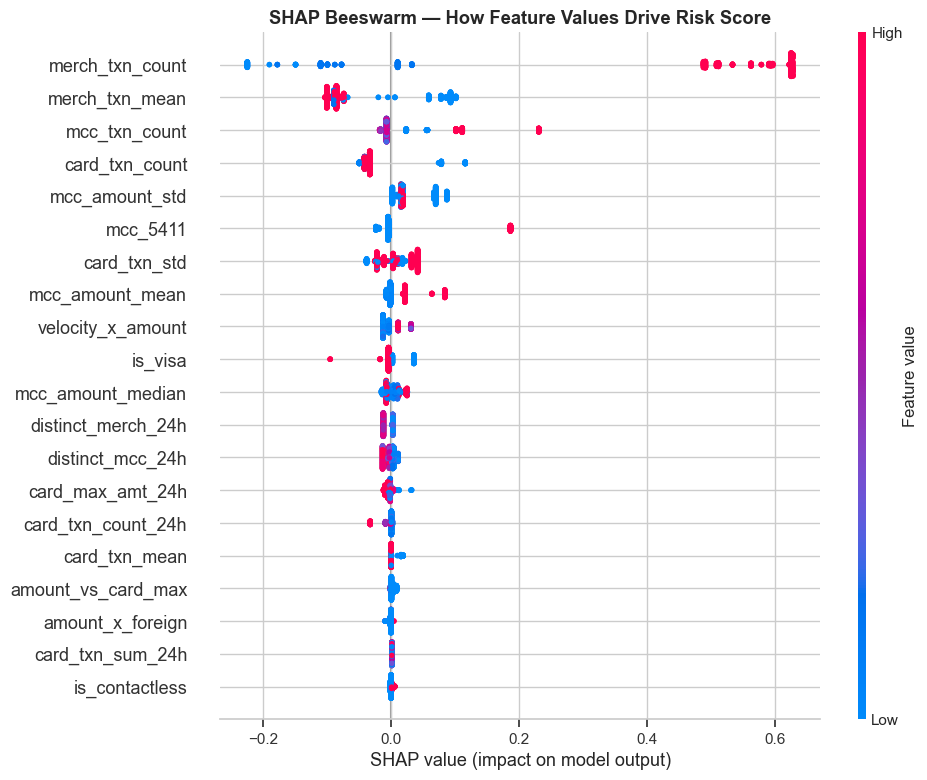

### Individual Case Explanations

Overall importance tells us what matters *in general*, but analysts need to understand **specific cases**. Below we show two contrasting examples from the test set:

For each case, we show the top features that influenced the score, along with whether they pushed the score toward fraud (RISK +) or away from it (RISK -).

```
CASE EXPLANATION: Top-Ranked Confirmed Fraud (Test Set)
=================================================================
  Case #1490 — CONFIRMED FRAUD
  Risk Score: 0.3870
=================================================================
  Feature                             Value       SHAP  Direction
  ------------------------------------------------------------
  merch_txn_count                   8917.00    +0.5333     RISK +
  card_txn_count                       0.00    +0.0781     RISK +
  merch_txn_mean                   74844.70    -0.0742     RISK -
  card_txn_std                         0.00    -0.0238     RISK -
  mcc_txn_count                       27.00    +0.0235     RISK +
  card_txn_mean                        0.00    +0.0152     RISK +
  mcc_amount_mean                   2040.74    -0.0074     RISK -
  is_visa                              1.00    -0.0043     RISK -
  card_max_amt_24h                  1600.00    -0.0042     RISK -
  velocity_x_amount                   88.54    -0.0038     RISK -


CASE EXPLANATION: Lowest-Ranked Confirmed Non-Fraud (Test Set)
=================================================================
  Case #1501 — CONFIRMED NON-FRAUD (clean)
  Risk Score: 0.3731
=================================================================
  Feature                             Value       SHAP  Direction
  ------------------------------------------------------------
  merch_txn_count                   8917.00    +0.6248     RISK +
  merch_txn_mean                   74844.70    -0.1007     RISK -
  card_txn_count                     567.00    -0.0334     RISK -
  mcc_amount_mean                 258746.20    +0.0212     RISK +
  mcc_amount_std                 4179404.50    +0.0136     RISK +
  velocity_x_amount                  281.07    -0.0129     RISK -
  card_max_amt_24h                 30000.00    -0.0123     RISK -
  card_txn_std                    603527.62    -0.0113     RISK -
  mcc_txn_count                     2397.00    -0.0076     RISK -
  mcc_5411                             0.00    -0.0050     RISK -
```

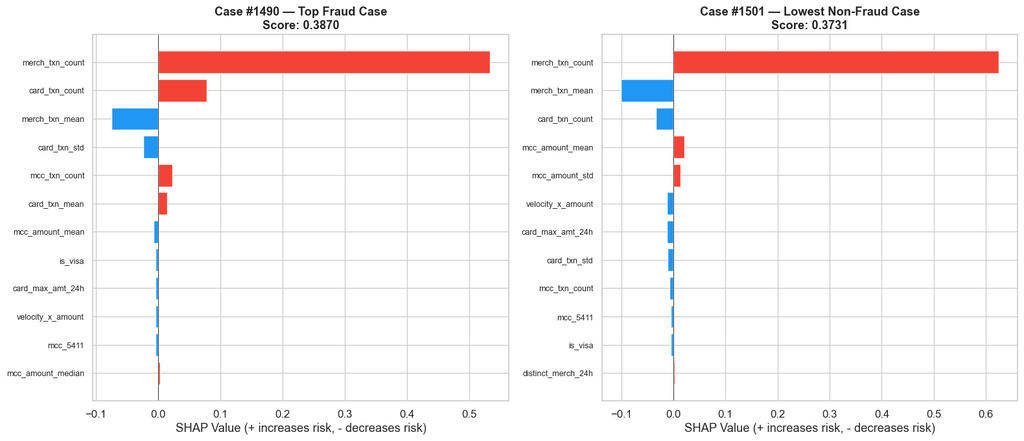

```
Red bars = features pushing the score TOWARD fraud
Blue bars = features pushing the score AWAY from fraud
```

### How Feature Values Affect Risk

The plots below show, for the top 4 most important features, how their values relate to the fraud risk score.

**How to read:** Each dot is a flagged transaction. Points above the zero line mean that feature **increased** the fraud risk score; points below mean it **decreased** the score. This reveals the patterns the model learned — for example, you might see that very high transaction amounts sharply increase fraud risk, while moderate amounts have little effect.

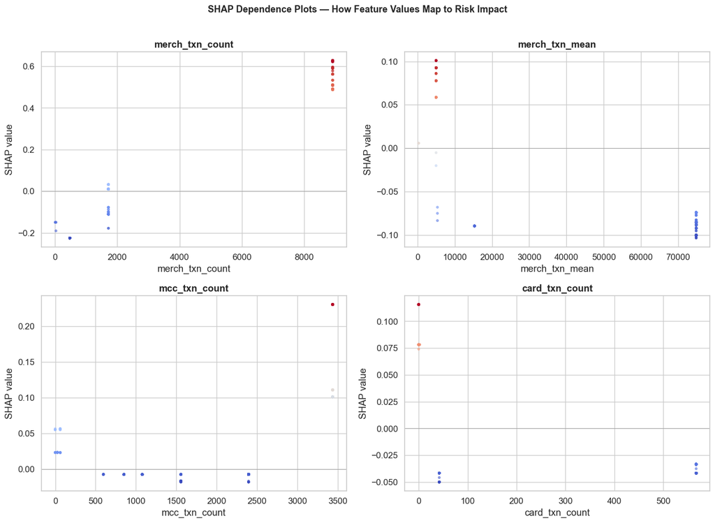

## 4. Business Impact

### What This Means for Operations

The charts below show the real-world impact of using the model to prioritize analyst work:

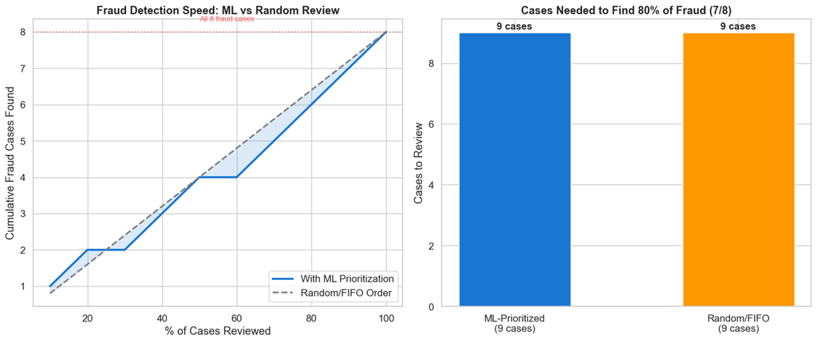

```
To find 80% of fraud (7 cases):
  ML model:   review 9 cases
  Random:     review 9 cases (expected)
```

## 5. Key Takeaways

### Limitations

- **Very small evaluation set.** Only 10 confirmed cases exist in the test set (8 fraud, 2 non-fraud). This is too few to draw strong statistical conclusions. The case-level AUC (0.44) is below the 0.50 random baseline, but with only 2 non-fraud cases, a single misranking swings AUC by over 6 percentage points — the result is noise, not signal.
- **Why so few confirmed cases?** Non-fraud confirmations (status 750) take much longer to resolve than fraud confirmations — median 73 days vs 22 days. Because the test window is limited, very few non-fraud resolutions fall within it. This is a data maturity problem, not a model problem.
- **Base rate makes Precision@K misleading.** With 8 out of 10 confirmed test cases being fraud, even random review would achieve ~80% precision — the same as the model's P@5. We cannot conclude the model outperforms random on this test slice.
- **What this means:** The test-set prioritization metrics are directional at best. Reliable evaluation requires either more analyst resolutions (especially non-fraud) or a longer data history to provide a larger, more balanced holdout set.